# Inférence paramétrique du modèle collectif à l'aide de données agrégées

Au cours d'une période d'exercice, le montant total des indemnisations est donné par

$$ X = \sum_{i = 1}^N U_i, $$

ou $N$ est une variable aléatoire de comptage et $(U_i)_{i\geq0}$ est une suite **iid** de variables aléatoires positives et indépendantes de $N$. Nous disposons d'un historique de données de $t$ périodes d'exercice, nous n'avons cependant pas accès aux données complètes

$$ n_s, \mathbf{u}_s = (u_{s,1},\ldots, u_{s,n_s}),\text{ }s=1,\ldots,t, $$

mais seulement à la somme des prestations

$$ x_s = \sum_{i = 1}^{n_s}u_{s,i},\text{ }s=1,\ldots, t. $$

qui sont des réalisations de la variable aléatoire $X$. On fait l'hypothèse d'un modèle paramétrique sur la distribution de la fréquence des sinistres $p(n|\theta_{\text{freq}})$ et sur les montants individuels des sinistres $f(u|\theta_{\text{sev}})$.

L'objectif est simple, proposer des estimateurs de $\theta_{\text{freq}}$ et $\theta_{\text{sev}}$ à partir des données $x_1,\ldots, x_t$.

Le modèle sous jacent est le suivant

$$N\sim \text{Geom}(q),\text{ avec }p(n|q) = q^n(1-q),\text{ }n \geq0\text{ et }U\sim \text{Exp}(\delta)\text{, avec }f_U(u|\delta) = \frac{e^{-u/\delta}}{\delta},\text{ }u>0.$$

```python
import numpy as np
import pandas as pd
import scipy as sc
import seaborn as sns
from scipy.optimize import minimize
import matplotlib.pyplot as plt
```

## Simulation de données agrégée

Ecrire une fonction **sim_X** pour simuler des réalisation de la variable $X$.

```python
t, q, δ = 10, 0.3, 5
def sim_X(t, q, δ):
    n_t = np.random.negative_binomial(1, 1-q, size=t)
    u_t = [np.random.exponential(scale = δ, size = n) for n in n_t]
    x_t = [np.sum(u) for u in u_t]
    return(np.array(x_t))
sim_X(t, q, δ)
```

```
array([ 0.        ,  4.09548659, 12.38933536,  0.        ,  2.47667854,
        0.        ,  0.        ,  0.        ,  0.        ,  0.        ])
```

## Estimateur du maximum de vraisemblance

La distribution de $X$ est mixte au sens ou

$$ \text{d}\mathbb{P}_X(x) = \mathbb{P}(N = 0)\text{d}\delta_0(x) + \sum_{n = 1}^{+\infty}f_U^{\ast n}(x)\mathbb{P}(N = n)\text{d}\lambda(x)= \mathbb{P}(N = 0)\text{d}\delta_0(x) + f^+_X(x)\text{d}\lambda(x) $$

Dans le cadre de notre modèle, nous avons

$$ \mathbb{P}(N = 0) = 1-q\text{, et }f^+_X(x) =\text{ ? } $$

On ré-arrange l'échantillon avec

$$ \mathbf{x} = (0,\ldots, 0, x_1^+,\ldots, x_{t-t_0}^+), $$

où $t_0$ désigne le nombre de $0$ et $x_1^+,\ldots, x_{t-t_0}^+$ les cumuls d'indemnisations des période d'exercice comportant au moins un sinistre.

**Comment définir la vraisemblance de l'échantillon $\mathbf{x}$?**

$$ L(\mathbf{x}|\theta) = \text{ ? } $$

**En générale on cherche à maximiser la logvraisemblance notée** $$ l(\mathbf{x}|\theta) = \log L(\mathbf{x}|\theta) = ? $$

**L'estimateur du maximum de vraisemblance est obtenu en résolvant le sytème**

$$ \begin{cases} \frac{\partial l}{\partial q}=0\\ \frac{\partial l}{\partial \delta}=0 \end{cases} $$

Ecrire une fonction **mle** permettant de trouver l'estimateur du maximum de vraisemblance

```python
X = sim_X(1000, q, δ)
def mle(X):
    t, t0 = len(X), np.sum(X ==0)
    q_mle = (t-t0)/t
    δ_mle =  t0 / t * np.sum(X) /(t-t0)
    return(q_mle, δ_mle)
```

Faire la même chose en utilisant la fonction minimize de la librairie scipy.optimize [minimize function](https://docs.scipy.org/doc/scipy/reference/generated/scipy.optimize.minimize.html#scipy.optimize.minimize) (voir aussi les [exemples](https://scipy-lectures.org/advanced/mathematical_optimization/#full-code-examples))

## Estimation Bayésienne

### Metropolis Hasting

En inférence Bayésienne, le paramètre est supposé aléatoire $\theta \sim \pi(\theta)$ où $\pi(\cdot)$ est la loi a priori qui résume l'information sur le paramètre avant d'avoir vu les données. L'inférence Bayésienne repose sur la mise à jour de l'information a priori par la vraisemblance des données pour obtenir la loi a posteriori

$$ \pi(\theta|\mathbf{x}) = \frac{L(\mathbf{x}|\theta)\pi(\theta)}{\int_{\Theta}L(\mathbf{x}|\theta)\pi(\theta)\text{d}\theta} $$

L'intégrale est souvent difficile à évaluer d'où le recours à un algorithme de simulation pour générer des valeurs de paramètres suivant la loi à posteriori.

Nous utiliserons un algorithme MCMC (Markov Chain Monte Carlo) basé sur des pas de Metropolis-Hasting, voici le pseudo code

Pour $i=1,...,I$

1. Si $i = 1$ **Initialisation** par exemple $\theta_1\sim \pi(\theta)$ sinon Etape 2
2. **Perturbation** $\theta^\ast = \theta_i + \epsilon$, avec $\epsilon\sim\text{M-Normal}(0,\Sigma)$
3. **Acceptation/Rejet**, soit $U\sim\text{Unif([0,1])}$
   - Si $\min\left(1, \frac{L(\mathbf{x}|\theta^\ast)\pi(\theta^\ast)}{L(\mathbf{x}|\theta_i)\pi(\theta_i)}\right)> U$ acceptation et $\theta_{i+1} = \theta^\ast$
   - Sinon rejet et $\theta_{i+1} = \theta_i$

Le résultat est un échantillon $\theta_1,\ldots, \theta_I$ distribué suivant la loi a posteriori. Il est nécessaire de choisir judicieusement le paramètre $\Sigma$ de la perturbation pour obtenir un algorithme efficace.

Supposons des lois a priori uniformes et indépendantes

$$ \pi(\theta) = \pi(q)\cdot\pi(\delta) =\frac{1}{b_q- a_q}\mathbb{I}_{[a_q,b_q]}(q)\times \frac{1}{b_\delta- a_\delta}\mathbb{I}_{[a_\delta,b_\delta]}(\delta) $$

Ecrire une fonction **logp_geom_exp** qui prend en argument les données et retourne une fonction qui évalue la vraisemblance pour un jeu de paramètres

```python
t, q, δ = 100, 0.1, 5
X = sim_X(t, q, δ)
def logp_geom_exp(X):
    def logp(parms):
        q, δ = parms
        if np.logical_and(np.all(parms > 0), q < 1 ) :
            t0, t = np.sum(X == 0), len(X)
            return(t * np.log(1-q) + (t-t0) * np.log(1-q) + (t - t0) * np.log(q) -
                   (t - t0) * np.log(δ) - (1 - q) / δ * np.sum(X))
        else:
            return(-np.inf)
    return(logp)
logp = logp_geom_exp(X)
logp(np.array([q, δ]))
```

```
-46.814485463324615
```

Ecrire une fonction **sim_post_sample_MH** pour simuler depuis la loi à posteriori, le résultat doit être un data frame contenant les valeurs simulés pour chacun des paramètres $q$ et $\delta$.

```python
parms_name = ['q', 'δ']
a_q, b_q, a_δ, b_δ = 0, 1, 0, 100
Σ, n_step = np.diag(np.array([0.01, 1])), 10000
def sim_post_sample_MH(X, parms_name, a_q, b_q, a_δ, b_δ, Σ, n_step):
    logp = logp_geom_exp(X)
    trace = []
    accepted = []
    q0, δ0 = np.random.uniform(low = a_q, high = b_q, size = 1), np.random.uniform(low = a_δ, high = b_δ, size = 1)
    trace.append(np.array([q0[0], δ0[0]])), accepted.append(True)
    for j in range(n_step):
        ϵ = np.random.multivariate_normal(mean = np.zeros(2), cov = Σ , size = 1)
        parms_old, parms_new = trace[-1], trace[-1] + ϵ[0]
        u = np.random.uniform(0, 1, size = 1)
        if logp(parms_new) - logp(parms_old) > np.log(u):
            trace.append(parms_new), accepted.append(True)
        else:
            trace.append(parms_old), accepted. append(False)
    trace, accepted
    trace_df = pd.DataFrame(trace)
    trace_df.columns = parms_name
    trace_df['accepted'] = np.array(accepted)
    return(trace_df)

trace = sim_post_sample_MH(X, parms_name, a_q, b_q, a_δ, b_δ, Σ, n_step)
np.mean(trace)
```

```
q            0.072419
δ           10.380515
accepted     0.265873
dtype: float64
```

```
array([0.1540923 , 0.14132258, 0.14132258, ..., 0.12513508, 0.1114039 ,
       0.1114039 ])
```

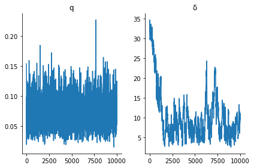

```python
fig, axs = plt.subplots(1,2)
for j in range(len(parms_name)):
    axs[j].plot(trace[parms_name[j]].values)
    axs[j].set_title(parms_name[j])
sns.despine()
fig.tight_layout()
trace['q'].values
```

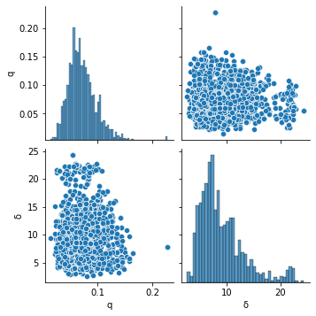

```python
sns.pairplot(trace[parms_name].loc[int(n_step/2):n_step])
sns.despine()
```

### Echantilloneur de Gibbs

Lorsque la dimension de l'espace des paramètres est plus grand que $1$ (deux dans notre cas), il est possible de simuler la loi a posteriori, soit la loi jointe $q,\delta|x$ composante par composante via l'algorithme suivant

On initialise aléatoirement par exemple via la loi a priori $(q_1,\delta_1)\sim\pi(q,\delta)$

Pour $i = 1,\ldots, I$

1. Simuler $q_{i+1}\sim\pi(q|\delta_i,x)$
2. Simuler $\delta_{i+1}\sim\pi(\delta|q_{i+1},x)$

Le résultat est une suite de réalisations $(q_1,\delta_1),\ldots, (q_I,\delta_I)$ d'une chaine de Markov dont la loi stationnaire est la loi a posteriori.

Cet méthode d'échantillonage, dite de Gibbs, requiert la connaissance des lois conditionnelles de $q|\delta,x$ et $\delta|q,x$ qui sont potentiellement plus facile à déterminer que la loi a posteriori $\pi(q,\delta|x)$.

Supposons que $\delta\sim \text{Inverse-Gamma}(\alpha,\beta)$ de densité

$$ \pi(\delta) = \frac{\beta^\alpha e^{-\beta/\delta}}{\Gamma(\alpha)\delta^{\alpha+1}},\text{ pour }\delta>0. $$

Adaptons le code précédent pour échantilloner la loi a posteriori via un échantilloneur de Gibbs. On suppose que $\delta\sim \text{Inverse-Gamma}(a_\delta,b_\delta)$ et $q\sim \text{Unif}([a_q, b_q])$. La mise à jour du paramètre $q$ s'effectue via des itération Metropolis Hasting. Ecrire la fonction **sim_post_sample_Gibbs**

```python
parms_name = ['q', 'δ']
a_δ, b_δ, a_q, b_q = 1, 1, 0, 1
σ, n_step = 0.01, 10000
def sim_post_sample_Gibbs(X, parms_name, a_δ, b_δ, a_q, b_q, σ, n_step):
    logp = logp_geom_exp(X)
    t, t0 = len(X), np.sum(X == 0)
    trace = []
    accepted = []
    q0, δ0 = np.random.uniform(low = a_q, high = b_q, size = 1), 1 / np.random.gamma(shape = a_δ, scale = 1 / b_δ, size = 1)
    trace.append(np.array([q0[0], δ0[0]])), accepted.append(True)
    for j in range(n_step):
        q_old, δ_old = trace[-1]
        δ_new = 1 / np.random.gamma(shape = (t - t0) + a_δ + 1 , scale = 1 / ((1- q_old)*np.sum(X) + b_δ), size = 1)
        q_new = np.random.normal(q_old, σ)
        u = np.random.uniform(0, 1, size = 1)
        if logp(np.array([q_new, δ_new[0]])) - logp(np.array([q_old, δ_old])) > u:
            trace.append(np.array([q_new, δ_new[0]])), accepted.append(True)
        else:
            trace.append(np.array([q_old, δ_new[0]])), accepted.append(False)
    trace_df = pd.DataFrame(trace)
    trace_df.columns = parms_name
    trace_df['accepted'] = np.array(accepted)
    return(trace_df)
trace = sim_post_sample_Gibbs(X, parms_name, a_δ, b_δ, a_q, b_q, σ, n_step)
```

```
array([0.06620961, 0.09634418, 0.09634418, ..., 0.08984419, 0.08984419,
       0.08984419])
```

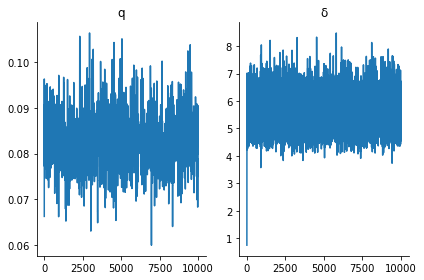

```python
fig, axs = plt.subplots(1,2)
for j in range(len(parms_name)):
    axs[j].plot(trace[parms_name[j]].values)
    axs[j].set_title(parms_name[j])
sns.despine()
fig.tight_layout()
trace['q'].values
```

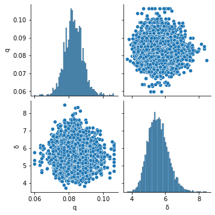

```python
sns.pairplot(trace[parms_name].loc[2500:n_step])
sns.despine()
```

## Estimation Bayésienne approchée

Lorsque la vraisemblance n'est pas accessible, (ce serait le cas en considérant d'autres distributions pour la fréquence et le montant des sinistres) il existe une technique pour s'affranchir de l'absence de vraisemblance via des simulations. L'algorithme est le suivant

Tant que $i < I $

1. $\theta^\ast\sim\pi(\theta)$
2. $\mathbf{x}^\ast\sim p(\mathbf{x}|\theta^\ast)$
3. - Si $D(\mathbf{x}, \mathbf{x}^\ast) <\epsilon$ alors $\theta_i =\theta^\ast$ et $i = i+1$
   - Sinon Etape 1

où $D(\cdot,\cdot)$ est une mesure de dissimilarité entre les données observées $\mathbf{x}$ et simulées $\mathbf{x}^\ast$ Le résultat est un échantillon distribué suivant la loi a posteriori approchée

$$ \pi_{abc}(\theta|\mathbf{x})=\frac{ \int_{\mathbb{R}^t}L(\mathbf{x}^\ast|\theta)\mathbb{I}_{D(\mathbf{x}, \mathbf{x^\ast}) <\epsilon}\text{d}\mathbf{x}^\ast\pi(\theta)}{\int_{\Theta}\int_{\mathbb{R}^t}L(\mathbf{x}^\ast|\theta)\mathbb{I}_{D(\mathbf{x}, \mathbf{x^\ast}) <\epsilon}\text{d}\mathbf{x}^\ast\pi(\theta)\text{d}\theta} $$

La précision est bien entendu liée au choix de $\epsilon$, il s'agit d'un compromis précision/temps de calcul. Le paramètre important est la distance $D$ permettant la comparaison des données observées et simulées. Le choix d'une distance euclidienne $$ D(x,x^\ast) = \sqrt{\sum_{s = 1}^t(x_s - x_s^\ast)^2} $$

conduit a ne jamais sélectionner de paramètre eu égard à une trop grande variance (pour de grands échantillons). Une solution consiste à définir des résumés statistiques

$$ S:x\mapsto S(x)\in\mathbb{R}^{d},\text{ avec } d\leq t $$

puis de mesurer la dissimilarité entre données observées et données simulées par $D[S(x),S(x^\ast)]$. L'utilisation de statistiques rajoute une approximation puisque la loi a posteriori approché converge vers la loi des paramètres sachant $S(x)$ ce qui correspond à une perte d'information.

Proposer une distance $D$ pour comparer les données simulées et observées. Ecrire une fonction **distance** prenant en argument le nom d'une distance et renvoyant une fonction prenant en argument $X$ et $X^\ast$ calculant la distance $D[S(x),S(x^\ast)]$.

```python
def distance(name):
    def D(X, X_ast):
        if name == "Wasserestein":
            return(np.sqrt(np.sum(np.sort(X)-np.sort(X_ast))**2))
        elif name == "stat_ex":
            t0, t0_ast = np.sum(X == 0), np.sum(X_ast == 0)
            return(np.sqrt( (t0 - t0_ast)**2 + (np.sum(X) - np.sum(X_ast))**2))
    return(D)
```

Ecrire une fonction **sim_post_sample_ABC** produisant des échantillons suivant la loi a posteriori approchée.

```python
def sim_post_sample_ABC(X, parms_name, a_q, b_q, a_δ, b_δ, n_step, ϵ, name_distance):
    trace, i = [], 0
    D = distance(name_distance)
    while i < n_step:
        q_ast, δ_ast = np.random.uniform(low = a_q, high = b_q, size = 1), np.random.uniform(low = a_δ, high = b_δ, size = 1)
        X_ast = sim_X(t, q_ast, δ_ast)
        if D(X, X_ast) < ϵ :
            trace.append(np.array([q_ast[0], δ_ast[0]]))
            i = i +1
    trace_df = pd.DataFrame(trace)
    trace_df.columns = parms_name
    return(trace_df)
```

```python
t, q, δ = 100, 0.1, 5
X = sim_X(t, q, δ)
parms_name = ['q', 'δ']
a_q, b_q, a_δ, b_δ = 0, 1, 0, 10
n_step_abc, ϵ_abc, name_distance = 1000, 10, "stat_ex"
Σ, n_step_MH =np.diag(np.array([0.01, 1])), 5000
trace_abc, trace_MH = sim_post_sample_ABC(X, parms_name, a_q, b_q, a_δ, b_δ, n_step_abc, ϵ_abc, name_distance), sim_post_sample_MH(X, parms_name, a_q, b_q, a_δ, b_δ, Σ, n_step_MH)
```

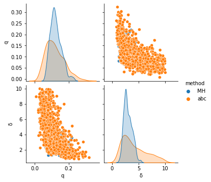

```python
trace_abc["method"] = np.repeat("abc",len(trace_abc) )
trace_MH["method"] = np.repeat("MH",len(trace_MH))
trace = pd.concat([trace_MH.drop(columns = ['accepted']).iloc[int(n_step_MH - n_step_abc):n_step_MH], trace_abc])
sns.pairplot(trace[np.append(parms_name, "method")], hue = "method")
sns.despine()
```